# Assignment 1

# Visualization

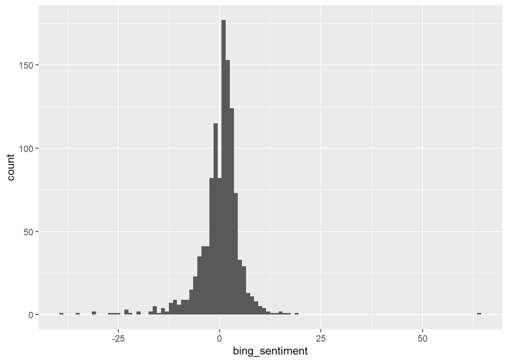

```r
# Histogram of sentiment scores
ggplot(df_with_sentiment, aes(x = bing_sentiment)) +
  geom_histogram(binwidth = 1)
```

[figure not shown]

```r
# Average Sentiment by Title
Book_sentiment <- df_with_sentiment %>%
  group_by(Title) %>%
  summarize(Average_Bing_Sentimet = mean(bing_sentiment))

#bar plot
ggplot(Book_sentiment, aes(x = reorder(Title, Average_Bing_Sentimet), y = Average_Bing_Sentimet, fill = Title)) +
  geom_bar(stat = "identity") +
  coord_flip() +
  labs(title = "Average Sentiment Score by Title", x = "Title", y = "Average Sentiment Score")
```

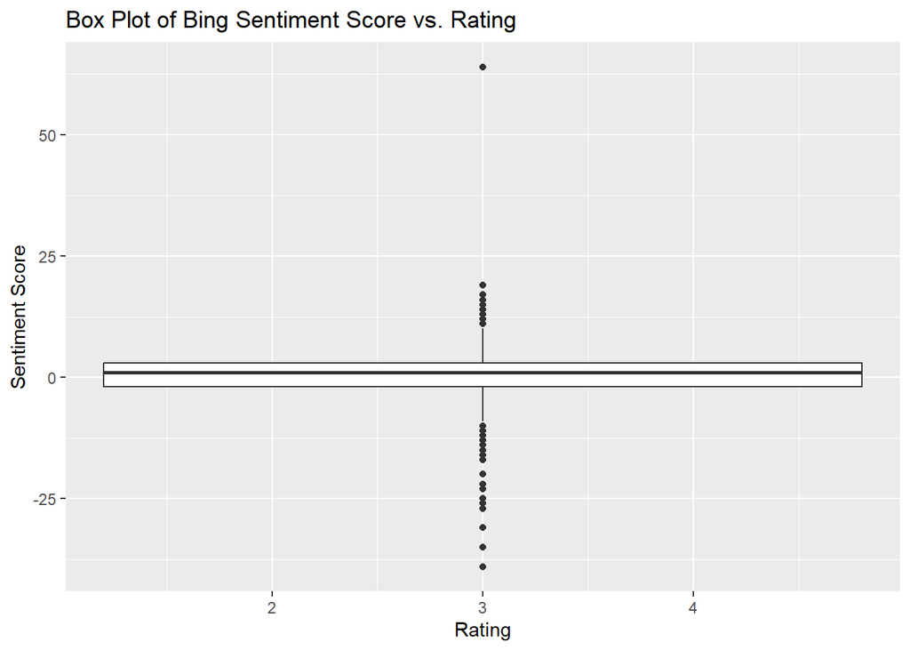

```r
# Box Plot of Sentiment against rating
ggplot(df_with_sentiment, aes(x = Rating, y = bing_sentiment)) +
  geom_boxplot() +
  labs(title = "Box Plot of Bing Sentiment Score vs. Rating",
       x = "Rating",
       y = "Sentiment Score")
```

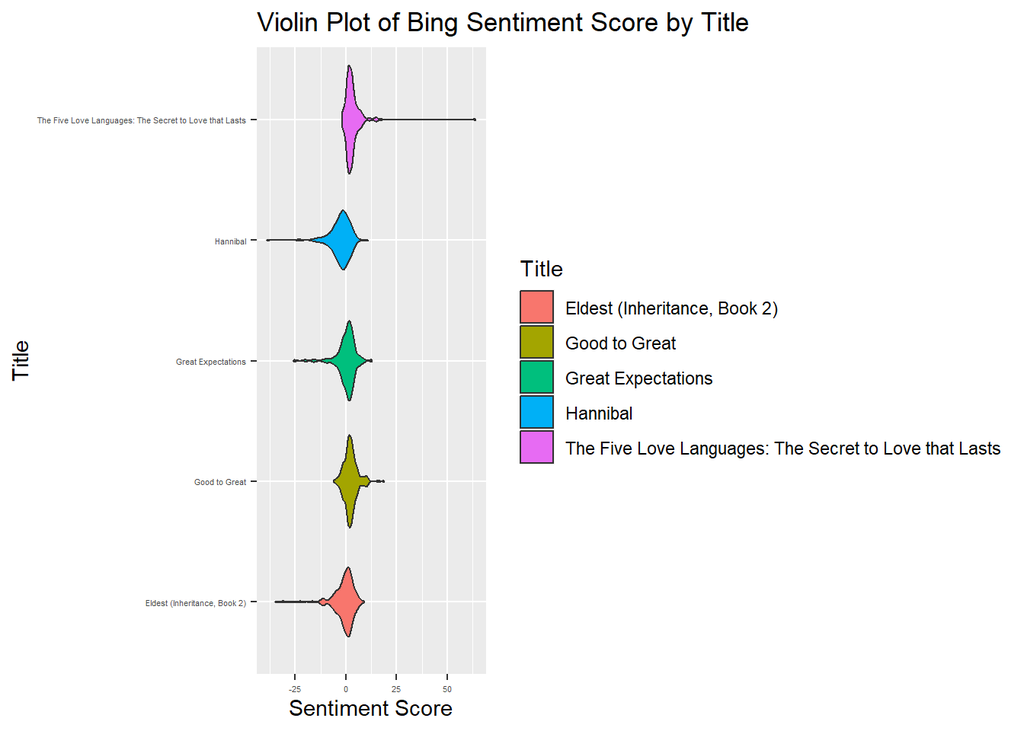

```r
# Violin Plot of Sentiment by Title
violin_plot <- ggplot(df_with_sentiment, aes(x = Title, y = bing_sentiment, fill = Title)) +
  geom_violin() +
  labs(title = "Violin Plot of Bing Sentiment Score by Title",
       x = "Title",
       y = "Sentiment Score") +
  coord_flip() +
  theme(axis.text = element_text(size =4))  # Adjust the size as needed

# Display the violin plot
print(violin_plot)
```

# 2.AFINN lexicon

The AFINN lexicon scores words with integers between -5 and +5 reflecting the words sentiment value. Negative numbers indicate negative sentiment & positive numbers indicate positive sentiment, and magnitude reflects the intensity of the sentiment.

```r
#retrieves sentiment scores from the AFINN lexicon and stores them in the afinn_sentiments data frame
afinn_sentiments <- get_sentiments("afinn")

summary(afinn_sentiments)
```

```
##      word               value
##  Length:2477        Min.   :-5.0000
##  Class :character   1st Qu.:-2.0000
##  Mode  :character   Median :-2.0000
##                     Mean   :-0.5894
##                     3rd Qu.: 2.0000
##                     Max.   : 5.0000
```

```r
#unique sentiment values from the AFINN lexicon, sorted in ascending order
print(sort(unique(afinn_sentiments$value)))
```

```
##  [1] -5 -4 -3 -2 -1  0  1  2  3  4  5
```

```r
set.seed(4)
afinn_sentiments[sample(nrow(afinn_sentiments), 10),]
```

```
## # A tibble: 10 × 2
##    word       value
##    <chr>      <dbl>
##  1 mischief      -1
##  2 deferring     -1
##  3 protects       1
##  4 adventures     2
##  5 disasters     -2
##  6 weird         -2
##  7 slash         -2
##  8 disturbs      -2
##  9 disdain       -2
## 10 bothers       -2
```

# Apply AFINN lexicon

```r
# Create dataset containing only words with associated sentiment & adds sentiment column.
sentiment_data <- clean_tokens %>%
  inner_join(get_sentiments("afinn"), by = "word")

# Calculate Sentiment scores for each review
sentiment_score <- sentiment_data %>%
  group_by(Review_no) %>%
  summarize(afinn_sentiment = sum(value))

# Merge with df
df_with_sentiment = df_with_sentiment %>%
  inner_join(sentiment_score, by = "Review_no")
```

Let’s inspect the reviews with highest and lowest sentiment

```r
worst_reviews = df_with_sentiment[order(df_with_sentiment$afinn_sentiment)[1],"Review_text"]

for (review in worst_reviews){
  print(review)
}
```

```
## [1] "Having just rewatched SILENCE OF THE LAMBS, and desperately needing some low-brow entertainment, I bought HANNIBAL. Although Harris can be compelling in parts, he allows minor characters to take up loads of space with their banal babbling, while Starling's major nemeses are two-dimensional c…
```

```r
best_reviews = df_with_sentiment[order(df_with_sentiment$afinn_sentiment, decreasing = TRUE)[1],"Review_text"]

for (review in best_reviews){
  print(review)
}
```

```
## [1] "As of the time I am writing this review 368 out of 398 reviewers gave this book a 4 or 5 star rating - that's 92% \"I liked it\" and \"I loved it\" ratings. With these many positive reviews there are some critical reviews as well that are worth reading to get a balanced overall review - ther…
```

# Visualization

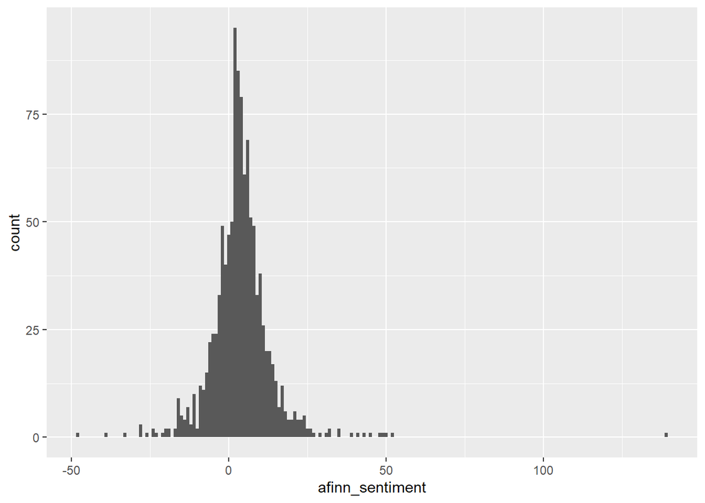

```r
# Histogram of sentiment scores
ggplot(df_with_sentiment, aes(x = afinn_sentiment)) +
  geom_histogram(binwidth = 1)
```

[figure not shown]

```r
# Average Sentiment by Title
book_sentiment <- df_with_sentiment %>%
  group_by(Title) %>%
  summarize(Average_Afinn_Sentimet = mean(afinn_sentiment))

ggplot(book_sentiment, aes(x = reorder(Title, Average_Afinn_Sentimet), y = Average_Afinn_Sentimet, fill = Title)) +
  geom_bar(stat = "identity") +
  coord_flip() +
  labs(title = "Average Sentiment Score by Title", x = "Title", y = "Average Sentiment Score")
```

[figure not shown]

```r
# Box Plot of Sentiment against rating
ggplot(df_with_sentiment, aes(x = Rating, y = afinn_sentiment)) +
  geom_boxplot() +
  labs(title = "Box Plot of Bing Sentiment Score vs. Rating",
       x = "Rating",
       y = "Sentiment Score")
```

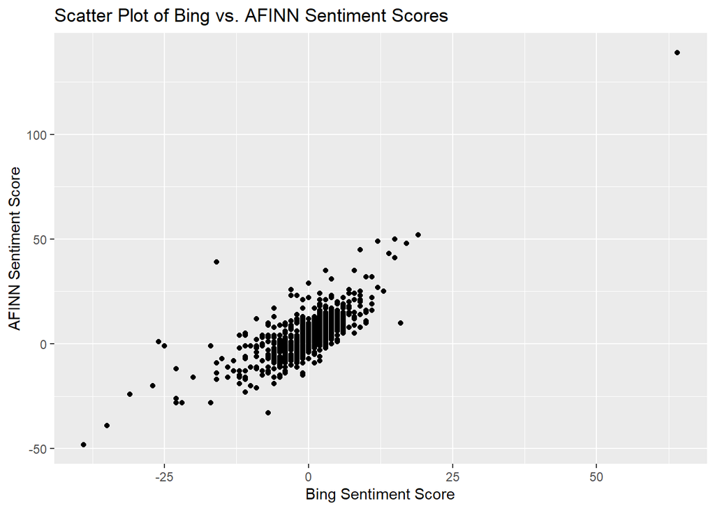

```r
# Scatter Plot of Bing vs. AFINN Sentiment
ggplot(df_with_sentiment, aes(x = bing_sentiment, y = afinn_sentiment)) +
  geom_point() +
  labs(title = "Scatter Plot of Bing vs. AFINN Sentiment Scores",
       x = "Bing Sentiment Score",
       y = "AFINN Sentiment Score")
```

```r
# Violin Plot of AFINN Sentiment by Title
violin_plot_afinn <- ggplot(df_with_sentiment, aes(x = Title, y = afinn_sentiment, fill = Title)) +
  geom_violin() +
  labs(title = "Violin Plot of AFINN Sentiment Score by Title",
       x = "Title",
       y = "AFINN Sentiment Score") +
  coord_flip()
  theme(axis.text = element_text(size =4))  # Adjust the size as needed
```

[output not shown]

[figure not shown]

```r
# Display the violin plot
print(violin_plot_afinn)
```

# 3.NRC lexicon

In applying the inner join you will receive the following warning “Warning: Detected an unexpected many-to-many relationship between `x` and `y`.”. This happens as the NRC lexicon has words with more than one emotion associated.This is handle by creating all combinations of pairings in the output data set.

```r
# Create dataset containing only words with associated sentiment & adds sentiment column.
emotion_data <- clean_tokens %>%
  inner_join(get_sentiments("nrc"), by = "word")
```

```
## Warning in inner_join(., get_sentiments("nrc"), by = "word"): Detected an unexpected many-to-many relationship between `x` and `y`.
## ℹ Row 1 of `x` matches multiple rows in `y`.
## ℹ Row 11774 of `y` matches multiple rows in `x`.
## ℹ If a many-to-many relationship is expected, set `relationship =
##   "many-to-many"` to silence this warning.
```

```r
# Calculate Sentiment scores for each review
emotion_count <- emotion_data %>%
  group_by(Review_no) %>%
  count(sentiment)

# Pivots data so that there is a column associated with each emotion
wide_emotion_data <- emotion_count %>%
  pivot_wider(names_from = sentiment, values_from = n, values_fill = list(n = 0))

# Merge with df
df_with_sentiment = df_with_sentiment %>%
  inner_join(wide_emotion_data, by = "Review_no")
```

```r
# Define emotions
emotions <- c("joy", "positive", "trust", "anticipation", "surprise", "sadness", "negative", "anger", "disgust", "fear")

# Loop through each emotion
for (emotion in emotions) {
  # Print the emotion being processed
  cat("\nReview with the highest score in", emotion, ":\n")

  # Get the review with the highest score for the current emotion
  index <- which.max(df_with_sentiment[[emotion]])
  review <- as.character(df_with_sentiment[index, "Review_text"])

  # Print the review
  cat(review, "\n")
}
```

```
##
## Review with the highest score in joy :
## As of the time I am writing this review 368 out of 398 reviewers gave this book a 4 or 5 star rating - that's 92% "I liked it" and "I loved it" ratings. With these many positive reviews there are some critical reviews as well that are worth reading to get a balanced overall review - there may act…
##
## Review with the highest score in positive :
## As of the time I am writing this review 368 out of 398 reviewers gave this book a 4 or 5 star rating - that's 92% "I liked it" and "I loved it" ratings. With these many positive reviews there are some critical reviews as well that are worth reading to get a balanced overall review - there may act…
##
## Review with the highest score in trust :
## As of the time I am writing this review 368 out of 398 reviewers gave this book a 4 or 5 star rating - that's 92% "I liked it" and "I loved it" ratings. With these many positive reviews there are some critical reviews as well that are worth reading to get a balanced overall review - there may act…
##
## Review with the highest score in anticipation :
## When I first heard about Eragon, I assumed it was just another popular fantasy series, much like Harry Potter or Animorphs, a book that was just literary candy, and not worth reading. I decided not to read it, and checked out other titles from the library. Justin received the book as a gift, and …
##
## Review with the highest score in surprise :
## When I first heard about Eragon, I assumed it was just another popular fantasy series, much like Harry Potter or Animorphs, a book that was just literary candy, and not worth reading. I decided not to read it, and checked out other titles from the library. Justin received the book as a gift, and …
##
## Review with the highest score in sadness :
## When I first heard about Eragon, I assumed it was just another popular fantasy series, much like Harry Potter or Animorphs, a book that was just literary candy, and not worth reading. I decided not to read it, and checked out other titles from the library. Justin received the book as a gift, and …
##
## Review with the highest score in negative :
## When I first heard about Eragon, I assumed it was just another popular fantasy series, much like Harry Potter or Animorphs, a book that was just literary candy, and not worth reading. I decided not to read it, and checked out other titles from the library. Justin received the book as a gift, and …
##
## Review with the highest score in anger :
## When I first heard about Eragon, I assumed it was just another popular fantasy series, much like Harry Potter or Animorphs, a book that was just literary candy, and not worth reading. I decided not to read it, and checked out other titles from the library. Justin received the book as a gift, and …
##
## Review with the highest score in disgust :
## When the very first line of a book is as nonsensical as "The songs of the dead are the lamentations of the living," you know you're in trouble.So it's pretty obvious from the start that Christopher Paolini's second novel "Eldest" is going to be a disaster. But the biggest weakness of Paolini's bo…
##
## Review with the highest score in fear :
## When I first heard about Eragon, I assumed it was just another popular fantasy series, much like Harry Potter or Animorphs, a book that was just literary candy, and not worth reading. I decided not to read it, and checked out other titles from the library. Justin received the book as a gift, and …
```

# Visualization

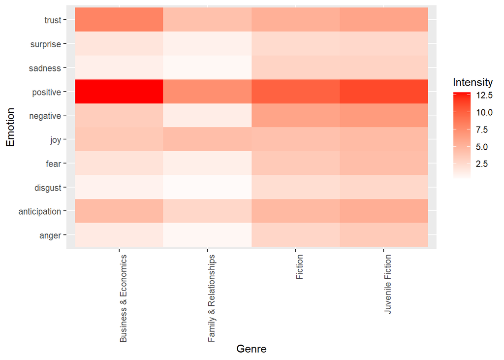

```r
long_df <- df_with_sentiment %>%
  pivot_longer(cols = c("joy", "positive", "trust", "anticipation", "surprise", "sadness", "negative", "anger", "disgust", "fear"),
               names_to = "Emotion",
               values_to = "Intensity")

emotion_scores <- long_df %>%
  group_by(Genre, Emotion) %>%
  summarize(avg_intensity = mean(Intensity),.groups='drop')

ggplot(emotion_scores, aes(x = Genre, y = Emotion, fill = avg_intensity)) +
  geom_tile() +  # Creates the heatmap tiles
  scale_fill_gradient2(low = "blue", high = "red") +  # Adjust colors
  labs(x = "Genre", y = "Emotion", fill = "Intensity") +
  theme(axis.text.x = element_text(angle = 90, hjust=1))  # Rotates text to 90 degrees and hjust=1 aligns text to the right
```

# 4.Emoji sentiment ranking

```r
# Create a custom emoji sentiment lexicon
emoji_lexicon <- data.frame(
  emoji = c("😊", "😢", "😡", "❤️", "👍", "👎"),  # Add more emojis as needed
  sentiment = c("positive", "negative", "negative", "positive", "positive", "negative"),
  stringsAsFactors = FALSE
)
summary(emoji_lexicon)
```

```
##     emoji            sentiment
##  Length:6           Length:6
##  Class :character   Class :character
##  Mode  :character   Mode  :character
```

```r
# print the unique sentiments label
print(unique(emoji_lexicon$sentiment))
```

```
## [1] "positive" "negative"
```

```r
set.seed(3)
# randomly samples 10 rows from the emoji_lexicon data frame
emoji_lexicon[sample(nrow(emoji_lexicon), 10, replace = TRUE),]
```

```
##     emoji sentiment
## 5       👍  positive
## 2       😢  negative
## 4       ❤️  positive
## 4.1     ❤️  positive
## 2.1     😢  negative
## 3       😡  negative
## 4.2     ❤️  positive
## 2.2     😢  negative
## 5.1     👍  positive
## 2.3     😢  negative
```

```r
# Apply emoji sentiment lexicon
sentiment_data_emoji <- clean_tokens %>%
  inner_join(emoji_lexicon, by = c("word" = "emoji"))

# Calculate sentiment scores for each review_no
sentiment_score_emoji <- sentiment_data_emoji %>%
  group_by(Review_no) %>%
  summarize(emoji_sentiment = sum(sentiment == "positive") - sum(sentiment == "negative"))

# Join the original sampled data frame (sample_df) with the calculated sentiment scores based on the "Review_no" column.
df_with_sentiment_emoji <- sample_df %>%
  inner_join(sentiment_score_emoji, by = "Review_no")

cat("\nEntire df_with_sentiment_emoji data frame:\n")
```

```
##
## Entire df_with_sentiment_emoji data frame:
```

```r
print(df_with_sentiment_emoji)
```

```
## # A tibble: 0 × 9
## # ℹ 9 variables: Title <chr>, Rating <int>, Review_title <chr>,
## #   Review_text <chr>, Publisher <chr>, First_author <chr>, Genre <chr>,
## #   Review_no <int>, emoji_sentiment <int>
```

```r
# Inspect the reviews with the highest and lowest sentiment
worst_reviews_emoji <- df_with_sentiment_emoji[order(df_with_sentiment_emoji$emoji_sentiment)[1], "Review_text"]

for (Review_text in worst_reviews_emoji) {
  print(Review_text)
}
```

```
## [1] NA
```

```r
best_reviews_emoji <- df_with_sentiment_emoji[order(df_with_sentiment_emoji$emoji_sentiment, decreasing = TRUE)[1], "Review_text"]

for (Review_text in best_reviews_emoji) {
  print(Review_text)
}
```

```
## [1] NA
```

# Conclusion

Analyzing the sentiment scores from three different sentiment analysis methods (Bing, Afinn, and NRC), observe a diverse range of emotions expressed in the provided reviews. Here are the key findings:

The Bing lexicon analysis of sentiment for the provided words reflects a diverse range of emotional tones associated with each term. The positive sentiments, such as “happily,” “revive,” “winner,” “reverence,” and “awestruck,” indicate favorable connotations, while the negative sentiments attached to words like “left-leaning,” “breach,” “heinous,” and “cataclysm” suggest unfavorable or adverse associations. The presence of both positive and negative sentiments in the lexicon underscores the complexity and nuance of language.The worst review criticizes the novel “HANNIBAL” for banal characters, two-dimensional antagonists, and perceived writing flaws, resulting in an overall negative assessment. On the other hand, the best review commends a book analyzing successful U.S. companies, appreciating its insights, sports analogy, and well-researched nature, emphasizing the subjective nature of opinions.

The Afinn lexicon assigns numerical values to words, indicating their sentiment polarity, with positive values for positive sentiments and negative values for negative sentiments. In the “worst one” excerpt, there are words with negative sentiments, such as “ludicrous,” “boring,” and “annoying.” The sentiment values assigned to these words in the Afinn lexicon would contribute to an overall negative sentiment for this text.In the “best one” excerpt, words like “significant,” “beneficial,” and “favorite” have positive sentiments, contributing to an overall positive sentiment for this text according to the Afinn lexicon.The worst review criticizes the novel “HANNIBAL” for character development, writing style, and perceived motivations, resulting in an overall negative assessment. On the contrary, the best review praises a book on marriage, highlighting the author’s expertise and positive reader ratings.

The NRC Emotion Lexicon extends beyond simple positive or negative categorizations. It encompasses a range of emotions such as joy, trust, anticipation, surprise, sadness, anger, and disgust. By counting the occurrences of words associated with each emotion, a more detailed and nuanced understanding of the emotional nuances in the reviews can be obtained. This lexicon is especially useful for capturing a broader spectrum of sentiments beyond just positive or negative.Finally cannot provide the best and worst reviews using Emoji sentiment ranking for this.

In conclusion, employing multiple lexicons enhances the depth and accuracy of sentiment analysis. While Bing provides a basic binary classification, AFINN introduces sentiment intensity, and NRC offers a richer emotional context. Depending on the level of granularity required in sentiment interpretation, these lexicons can be chosen accordingly for a more holistic understanding of the reviews’ sentiments.

# PART 3

#Creation of Term Document Matrix

```r
# Convert text column to corpus(create the corpus from review_text)
corpus <- VCorpus(VectorSource(sample_df$Review_text))

# Apply cleaning
corpus <- tm_map(corpus, content_transformer(tolower)) %>% #converts the text to lowercase
          tm_map(content_transformer(function(x) gsub("[^a-zA-Z ]", "", x))) %>% #Removes any characters that are not alphabets or spaces
          tm_map(removeWords, stopwords("en")) %>% #Removes English stopwords.
          tm_map(stemDocument) #Applies stemming to reduce words to their root form

# Convert to a term document matrix
tdm <- TermDocumentMatrix(corpus, control = list(wordLengths = c(4, 14)))

#converts the term-document matrix (tdm) to a standard matrix (tdm_matrix)
tdm_matrix <- as.matrix(tdm)
```

#Term Selection(term frequency)

```r
#sums the frequencies of each term across all documents in the term-document matrix
term_frequencies <- rowSums(tdm_matrix)

# Create a data frame with columns for terms and their corresponding frequencies
term_frequency_df <- data.frame(term = names(term_frequencies), frequency = term_frequencies)

# Sort the data frame by frequency in descending order and select the top 10
top_terms <- term_frequency_df %>%
  arrange(desc(frequency)) %>%
  head(10)

# Display the top 10 terms
print(top_terms)
```

```
##            term frequency
## book       book      2876
## read       read      1410
## great     great       915
## good       good       625
## love       love       583
## like       like       556
## will       will       539
## charact charact       531
## compani compani       476
## eragon   eragon       466
```

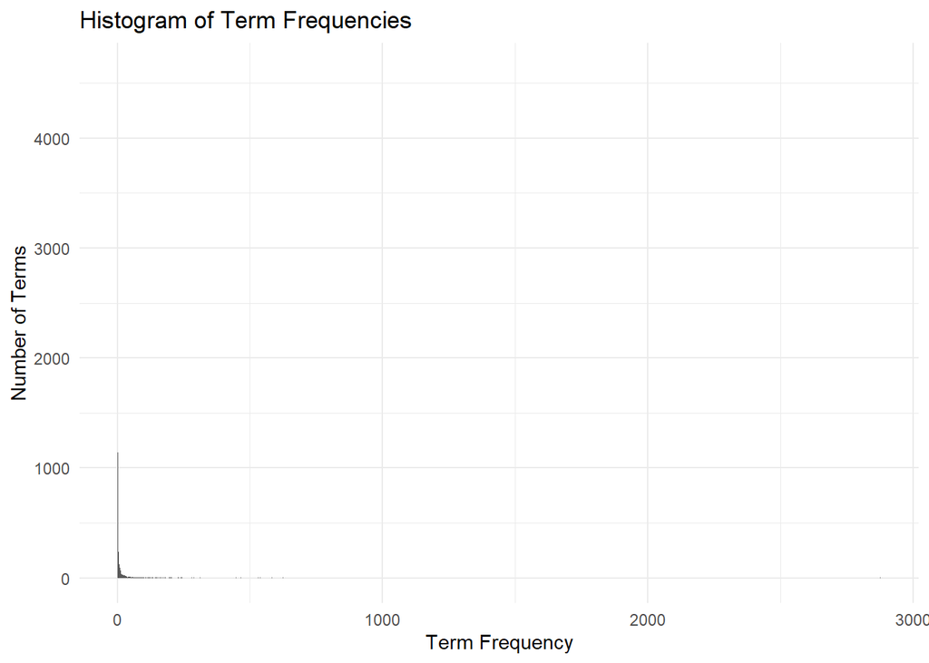

```r
# Create the histogram
ggplot(term_frequency_df, aes(x = frequency)) +
  geom_histogram(binwidth = 1) +
  labs(title = "Histogram of Term Frequencies",
       x = "Term Frequency",
       y = "Number of Terms") +
  theme_minimal()
```

```r
# Find terms that appear in more than 10% of documents
frequent_terms <- findFreqTerms(tdm, lowfreq = 0.10 * ncol(tdm_matrix))
# Find terms that appear in less than 0.01% of documents
rare_terms <- findFreqTerms(tdm, highfreq = 0.01 * ncol(tdm_matrix))

print("Frequent Terms")
```

```
## [1] "Frequent Terms"
```

```r
print(frequent_terms)
```

```
##  [1] "also"         "anoth"        "author"       "becom"        "best"
##  [6] "better"       "book"         "busi"         "cant"         "chang"
## [11] "chapter"      "charact"      "collin"       "come"         "compani"
## [16] "concept"      "dicken"       "didnt"        "differ"       "dont"
## [21] "dragon"       "eldest"       "enjoy"        "eragon"       "even"
## [26] "everi"        "expect"       "fantasi"      "feel"         "find"
## [31] "first"        "found"        "give"         "good"         "great"
## [36] "hannib"       "harri"        "help"         "high"         "interest"
## [41] "just"         "know"         "languag"      "last"         "learn"
## [46] "lecter"       "life"         "like"         "littl"        "long"
## [51] "look"         "love"         "made"         "make"         "mani"
## [56] "miss"         "movi"         "much"         "must"         "need"
## [61] "never"        "novel"        "page"         "paolini"      "part"
## [66] "peopl"        "person"       "plot"         "point"        "read"
## [71] "reader"       "realli"       "recommend"    "relationship" "review"
## [76] "right"        "seem"         "silenc"       "starl"        "still"
## [81] "stori"        "take"         "thing"        "think"        "though"
## [86] "thought"      "time"         "understand"   "want"         "well"
## [91] "will"         "wonder"       "work"         "world"        "write"
## [96] "written"      "year"
```

```r
print("First 10 Infrequent Terms")
```

```
## [1] "First 10 Infrequent Terms"
```

```r
print(rare_terms[1:10])
```

```
##  [1] "abandon"  "abash"    "abbott"   "abel"     "abet"     "abhor"
##  [7] "abhorr"   "abhorsen" "abnorm"   "abod"
```

```r
# Edit list of frequent words to keep useful ones
to_keep<-c("eldest", "eragon", "love", "compani")
to_remove <- frequent_terms[!frequent_terms %in% to_keep]
print(to_remove)
```

```
##  [1] "also"         "anoth"        "author"       "becom"        "best"
##  [6] "better"       "book"         "busi"         "cant"         "chang"
## [11] "chapter"      "charact"      "collin"       "come"         "concept"
## [16] "dicken"       "didnt"        "differ"       "dont"         "dragon"
## [21] "enjoy"        "even"         "everi"        "expect"       "fantasi"
## [26] "feel"         "find"         "first"        "found"        "give"
## [31] "good"         "great"        "hannib"       "harri"        "help"
## [36] "high"         "interest"     "just"         "know"         "languag"
## [41] "last"         "learn"        "lecter"       "life"         "like"
## [46] "littl"        "long"         "look"         "made"         "make"
## [51] "mani"         "miss"         "movi"         "much"         "must"
## [56] "need"         "never"        "novel"        "page"         "paolini"
## [61] "part"         "peopl"        "person"       "plot"         "point"
## [66] "read"         "reader"       "realli"       "recommend"    "relationship"
## [71] "review"       "right"        "seem"         "silenc"       "starl"
## [76] "still"        "stori"        "take"         "thing"        "think"
## [81] "though"       "thought"      "time"         "understand"   "want"
## [86] "well"         "will"         "wonder"       "work"         "world"
## [91] "write"        "written"      "year"
```

```r
filtered_tdm_matrix <- tdm_matrix[!rownames(tdm_matrix) %in% to_remove, ]
filtered_tdm_matrix <- filtered_tdm_matrix[!rownames(filtered_tdm_matrix) %in% rare_terms, ]


# Calculate column sums
column_sums <- colSums(filtered_tdm_matrix)

# Identify columns that are all zeros
zero_columns <- which(column_sums == 0)

# Remove these columns
if(length(zero_columns) > 0) {
  # Remove these columns
  filtered_tdm_matrix <- filtered_tdm_matrix[, -zero_columns]
} else {
  # If no columns are all zeros, just use the original matrix
  print("No zero columns in TDM matrix")
}
```

```r
#Calculating Word Frequencies for Filtered Matrix:
term_frequencies <- rowSums(filtered_tdm_matrix)

# Create a data frame with columns for terms and their corresponding frequencies
term_frequency_df <- data.frame(term = names(term_frequencies), frequency = term_frequencies)

# Sort the data frame by frequency in descending order and select the top 10
top_terms <- term_frequency_df %>%
  arrange(desc(frequency)) %>%
  head(10)

# Display the top 10 terms
print(top_terms)
```

```
##              term frequency
## love         love       583
## compani   compani       476
## eragon     eragon       466
## eldest     eldest       183
## anyon       anyon       120
## believ     believ       120
## howev       howev       120
## research research       120
## hope         hope       119
## success   success       119
```

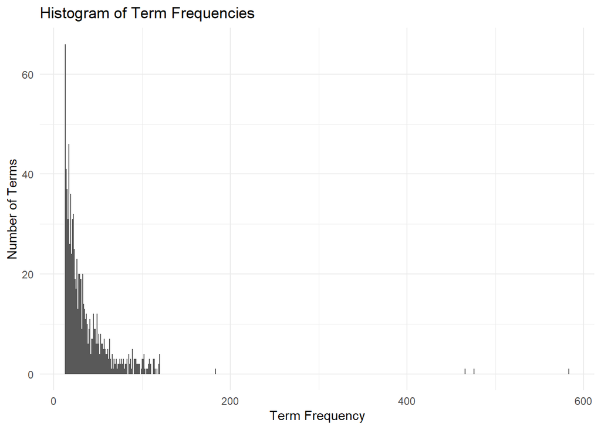

```r
# Create the histogram
ggplot(term_frequency_df, aes(x = frequency)) +
  geom_histogram(binwidth = 1) +
  labs(title = "Histogram of Term Frequencies",
       x = "Term Frequency",
       y = "Number of Terms") +
  theme_minimal()
```

#Create LDA Model

```r
#transposes the filtered term-document matrix to a document-term matrix
dtm <- t(filtered_tdm_matrix)

# Filter out rows with all zeros
non_zero_rows <- rowSums(dtm != 0) > 0
dtm <- dtm[non_zero_rows, ]

#k=number of topics
lda_model <- LDA(dtm, k = 4)
```

# LDA visualization

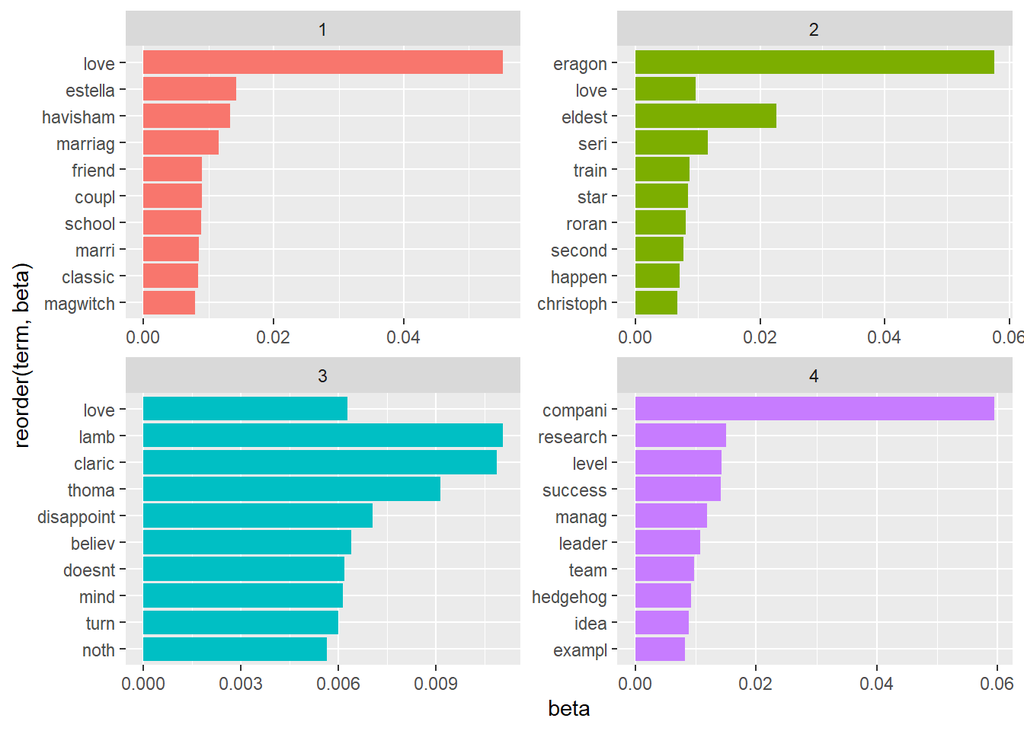

```r
topics <- tidy(lda_model, matrix = "beta")


top_terms <- topics %>%
  group_by(topic) %>%
  top_n(10, beta) %>%
  ungroup() %>%
  arrange(topic, -beta)

top_terms %>%
  ggplot(aes(x =reorder(term, beta), y = beta, fill = factor(topic))) +
  geom_col(show.legend = FALSE) +
  facet_wrap(~ topic, scales = "free") +
  coord_flip()
```

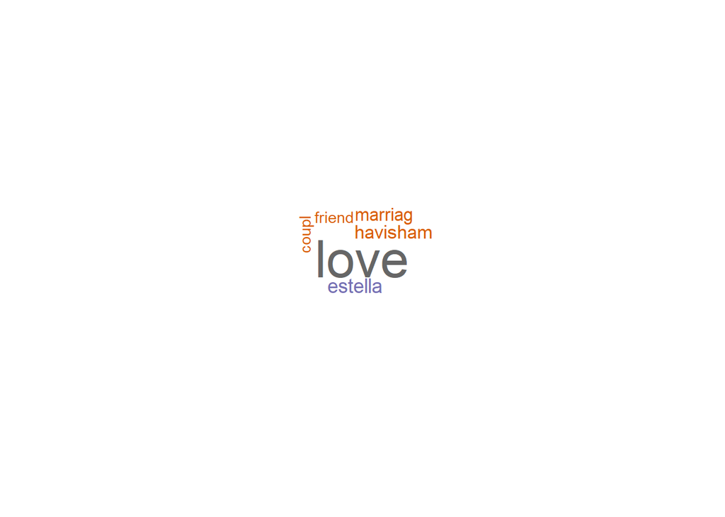

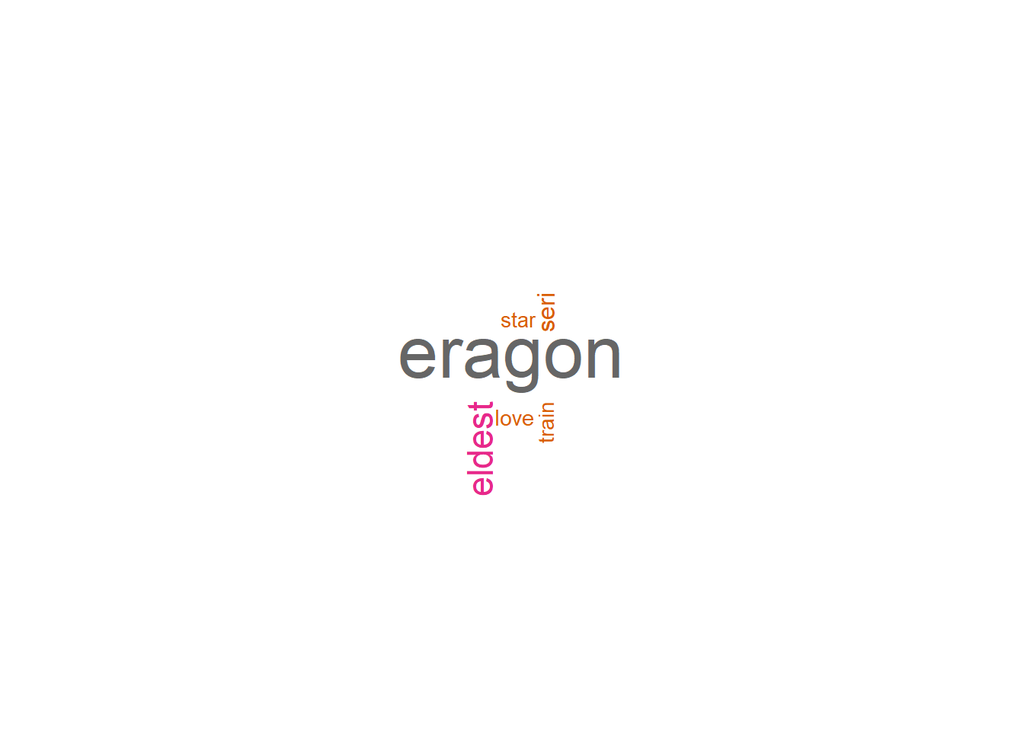

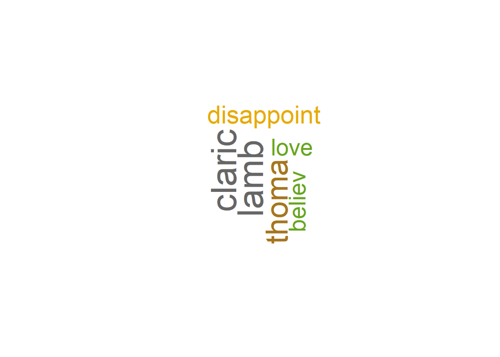

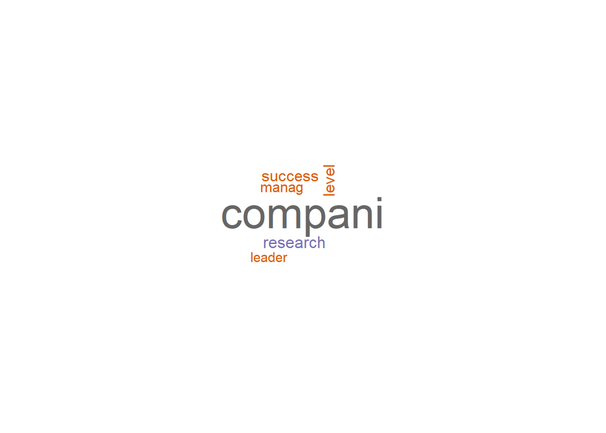

```r
# Save the plot as an image file (optional)
#ggsave("plot.png", width = 10, height = 8)

# Top terms for each topic
top_terms <- topics %>%
  group_by(topic) %>%
  top_n(6, beta) %>%
  ungroup() %>%
  arrange(topic, -beta)

# Plot word clouds for each topic
for (i in unique(top_terms$topic)) {
  terms <- top_terms %>%
    filter(topic == i) %>%
    select(term, beta) %>%
    arrange(desc(beta))

  wordcloud(words = terms$term, freq = terms$beta, scale = c(3, 0.5), min.freq = 1,
            colors = brewer.pal(8, "Dark2"), random.order = FALSE,
            rot.per = 0.35, use.r.layout = FALSE, max.words = 100)

  #to save each word cloud separately
  ggsave(paste0("wordcloud_topic_", i, ".png"), width = 8, height = 6)
}
```

### Heatmap visualization

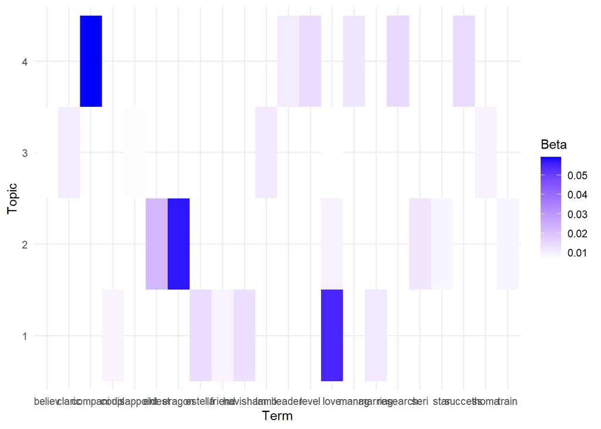

```r
# Create a heatmap
heatmap_plot <- top_terms %>%
  ggplot(aes(x = term, y = factor(topic), fill = beta)) +
  geom_tile() +
  scale_fill_gradient(low = "white", high = "blue") +  # Adjust colors as needed
  labs(x = "Term", y = "Topic", fill = "Beta") +
  theme_minimal()  # Adjust the theme as needed

print(heatmap_plot)
```

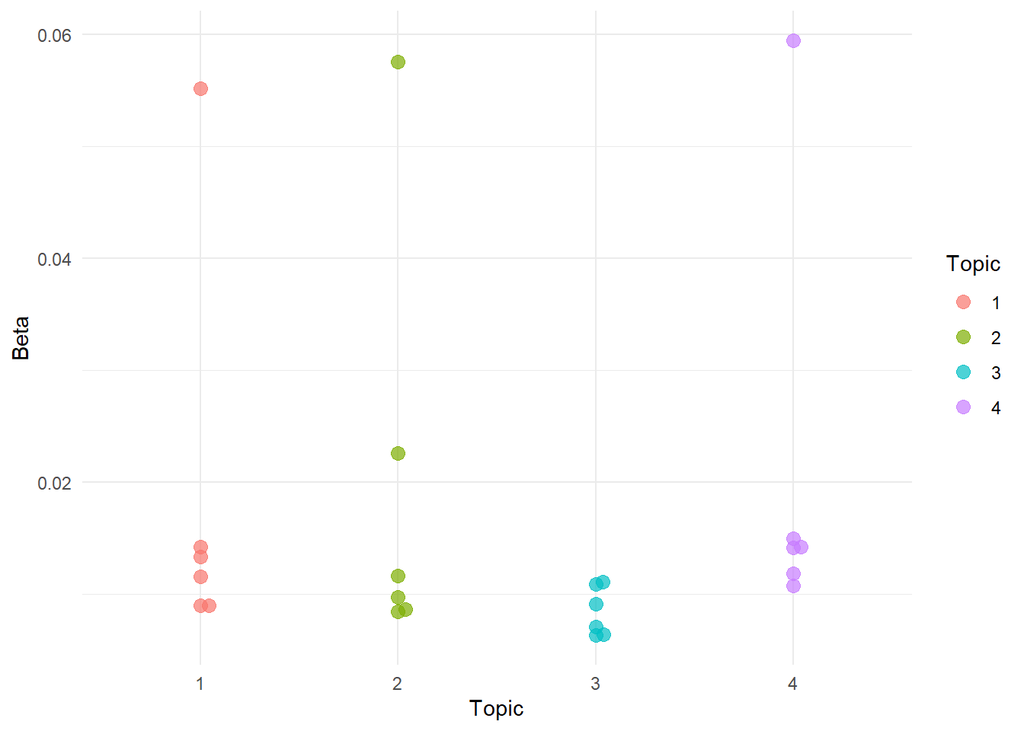

```r
# Create a beeswarm plot for the top terms in each topic
beeswarm_plot <- top_terms %>%
  ggplot(aes(x = factor(topic), y = beta, color = factor(topic))) +
  geom_beeswarm(alpha = 0.7, size = 3) +
  labs(x = "Topic", y = "Beta", color = "Topic") +
  theme_minimal()

print(beeswarm_plot)
```

#Choose k using perplexity plot

Metrics like perplexity can be used to help determine a good value of k. - **Perplexity** measures how well a probability distribution or probability model predicts a sample. Lower perplexity indicates a better model.Perplexity is like a score for how well the model understands new texts based on its training, with a lower score being better.

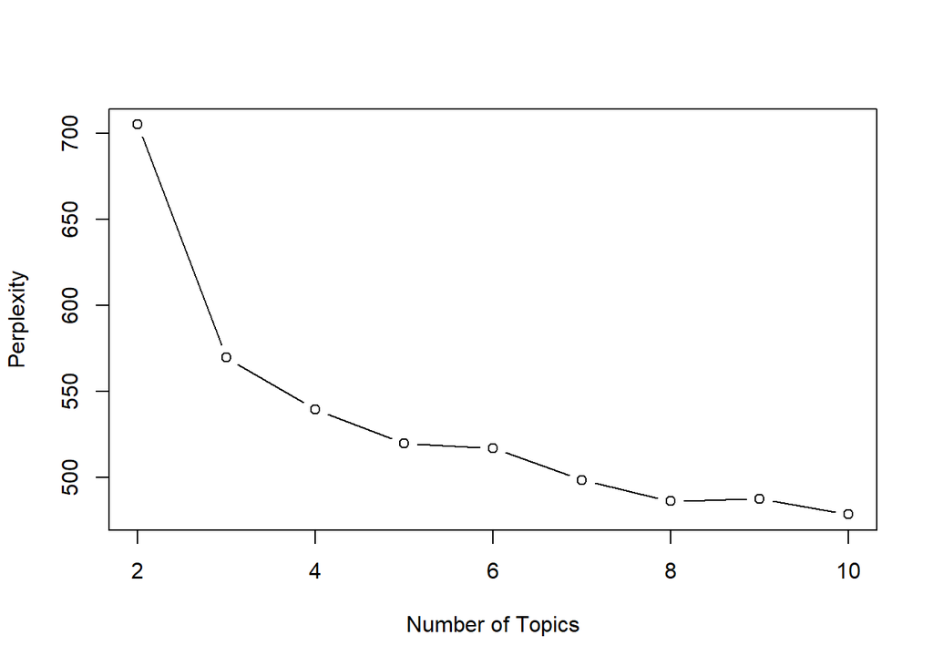

```r
#define the range of k
range_k <- seq(2,10, by = 1)  # Adjust the range as needed

#compute perplexity for each value k
perplexities <- sapply(range_k, function(k) {

  #fit LDA model with k using DTM
  model <- LDA(dtm, k = k, control = list(seed = 3))

  #calculate perplexity for fitted model
  perplexity(model)
})

# Plotting perplexities
plot(range_k, perplexities, type = "b", xlab = "Number of Topics", ylab = "Perplexity")
```

## LDAvis tool

```r
set.seed(1)
lda_model <- LDA(dtm, k = 3)

lda_vis_data <- createJSON(phi = posterior(lda_model)$terms,
                          theta = posterior(lda_model)$topics,
                          doc.length = rowSums(as.matrix(dtm)),
                          vocab = colnames(as.matrix(dtm)),
                          term.frequency = colSums(as.matrix(dtm)))
serVis(lda_vis_data)
```